# Hausaufgabe4 Teil 3

```r
library(tidyverse)
library(e1071)
library(caret)
library(pROC)
titanic <- read_delim("titanic.csv", ";",
    escape_double = FALSE, trim_ws = TRUE)
```

Das letzte Notebook habe ich mit dem Feature embarked (Wo die Passagiere dazugestiegen sind) erstellt.

```r
titanic_svm <- titanic %>%
  select(survived,pclass,age,sex,embarked) %>%
  mutate (age = as.numeric(str_replace(age,",","."))) %>%
  mutate (fare = as.numeric(str_replace(age,",","."))) %>%
  mutate(survived = as.factor(survived)) %>%
  mutate(sex = ifelse(sex == "female", 1, 0)) %>%
  mutate(embarked =replace(embarked, which(embarked =="C"), 0))  %>%
  mutate(embarked =replace(embarked, which(embarked =="Q"), 1))  %>%
  mutate(embarked =replace(embarked, which(embarked =="S"), 2))
```

```r
titanic_svm <- na.omit(titanic_svm)
titanic_svm <- titanic_svm
```

```r
train_control <- trainControl(method="cv", number=10, , savePredictions = TRUE)
```

```r
set.seed(393)
inTrain <- createDataPartition(
  y = titanic_svm$survived,
  p = .8,
  list = FALSE)
training <- titanic_svm[ inTrain,]
testing  <- titanic_svm[-inTrain,]
```

```r
model.svm <- train(survived~., data=training, trControl=train_control, method="svmLinear")
summary(model.svm)
```

```
## Length  Class   Mode
##      1   ksvm     S4
```

```r
pred <- predict(model.svm, testing[,-1], probability = FALSE)
```

```r
model.svm$pred
```

| pred | obs | rowIndex | C | Resample |
| --- | --- | --- | --- | --- |
| 1 | 1 | 17 | 1 | Fold01 |
| 1 | 1 | 29 | 1 | Fold01 |
| 0 | 0 | 32 | 1 | Fold01 |
| 1 | 1 | 39 | 1 | Fold01 |
| 1 | 1 | 41 | 1 | Fold01 |
| 0 | 0 | 60 | 1 | Fold01 |
| 1 | 1 | 61 | 1 | Fold01 |
| 0 | 1 | 62 | 1 | Fold01 |
| 1 | 1 | 76 | 1 | Fold01 |
| 1 | 1 | 88 | 1 | Fold01 |

[output cut: 826 more lines]

```r
(test.results <- cbind(pred, testing))
```

| pred | survived | pclass | age | sex | embarked | fare |
| --- | --- | --- | --- | --- | --- | --- |
| 0 | 1 | 1 | 0.9167 | 0 | 2 | 0.9167 |
| 1 | 1 | 1 | 18.0000 | 1 | 0 | 18.0000 |
| 1 | 1 | 1 | 24.0000 | 1 | 0 | 24.0000 |
| 0 | 0 | 1 | 24.0000 | 0 | 0 | 24.0000 |
| 0 | 0 | 1 | 25.0000 | 0 | 0 | 25.0000 |
| 0 | 0 | 1 | 42.0000 | 0 | 2 | 42.0000 |
| 1 | 1 | 1 | 59.0000 | 1 | 2 | 59.0000 |
| 1 | 1 | 1 | 60.0000 | 1 | 0 | 60.0000 |
| 0 | 0 | 1 | 45.0000 | 0 | 2 | 45.0000 |
| 1 | 1 | 1 | 58.0000 | 1 | 0 | 58.0000 |

[output cut: 198 more lines]

```r
test.results <- test.results %>%
  mutate(survived = as.numeric(survived)) %>%
  mutate(pred = as.numeric(pred))
```

```r
head(attr(pred, "probabilities"))
```

```r
table(test.results$pred, testing$survived)
```

```
##
##       0   1
##   1 111  26
##   2  12  59
```

```r
confusionMatrix(pred,testing$survived)
```

```
## Confusion Matrix and Statistics
##
##           Reference
## Prediction   0   1
##          0 111  26
##          1  12  59
##
##                Accuracy : 0.8173
##                  95% CI : (0.758, 0.8674)
##     No Information Rate : 0.5913
##     P-Value [Acc > NIR] : 2.589e-12
##
##                   Kappa : 0.6121
##
##  Mcnemar's Test P-Value : 0.03496
##
##             Sensitivity : 0.9024
##             Specificity : 0.6941
##          Pos Pred Value : 0.8102
##          Neg Pred Value : 0.8310
##              Prevalence : 0.5913
##          Detection Rate : 0.5337
##    Detection Prevalence : 0.6587
##       Balanced Accuracy : 0.7983
##
##        'Positive' Class : 0
##
```

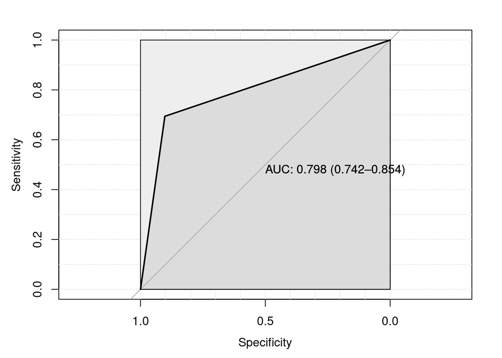

```r
pROC_obj <- roc(test.results$survived, test.results$pred,
            smoothed = TRUE,
            ci=TRUE, ci.alpha=0.9, stratified=FALSE,
            plot=TRUE, auc.polygon=TRUE, max.auc.polygon=TRUE, grid=TRUE,
            print.auc=TRUE, show.thres=TRUE)
```

Der Wert bei SVM verändert sich das einzige Mal, jedoch ins Negative

```r
saveRDS(model.svm, "./titanic.svm.rds")
```

Naive Bayes

```r
my_training <- training %>%
  mutate(survived = as.factor(survived))%>%
  mutate(sex = as.factor(sex))%>%
  mutate(pclass = as.factor(pclass)) %>%
  mutate(embarked = as.factor(embarked)) %>%
mutate(age = as.factor(ifelse(age < 14, "child", "adult")))
model <- naiveBayes(survived ~ ., data = my_training)
model
```

```
##
## Naive Bayes Classifier for Discrete Predictors
##
## Call:
## naiveBayes.default(x = X, y = Y, laplace = laplace)
##
## A-priori probabilities:
## Y
##         0         1
## 0.5933014 0.4066986
##
## Conditional probabilities:
##    pclass
## Y           1         2         3
##   0 0.1471774 0.2358871 0.6169355
##   1 0.4264706 0.2852941 0.2882353
##
##    age
## Y       adult     child
##   0 0.9233871 0.0766129
##   1 0.8735294 0.1264706
##
##    sex
## Y           0         1
##   0 0.8326613 0.1673387
##   1 0.3294118 0.6705882
##
##    embarked
## Y            0          1          2
##   0 0.13306452 0.06653226 0.80040323
##   1 0.31176471 0.02941176 0.65882353
##
##    fare
## Y       [,1]     [,2]
##   0 29.92053 13.70031
##   1 29.07525 14.55376
```

```r
my_testing <- testing %>%
  mutate(sex = as.factor(sex)) %>%
  mutate(pclass = as.factor(pclass))%>%
  mutate(embarked = as.factor(embarked)) %>%
  mutate(age = as.factor(ifelse(age < 7, "child", "adult")))
pred <- predict(model, my_testing)
table(pred, my_testing$survived)
```

```
##
## pred   0   1
##    0 104  26
##    1  19  59
```

```r
(test.results <- cbind(pred, my_testing))
```

| pred | survived | pclass | age | sex | embarked | fare |
| --- | --- | --- | --- | --- | --- | --- |
| 1 | 1 | 1 | child | 0 | 2 | 0.9167 |
| 1 | 1 | 1 | adult | 1 | 0 | 18.0000 |
| 1 | 1 | 1 | adult | 1 | 0 | 24.0000 |
| 1 | 0 | 1 | adult | 0 | 0 | 24.0000 |
| 1 | 0 | 1 | adult | 0 | 0 | 25.0000 |
| 0 | 0 | 1 | adult | 0 | 2 | 42.0000 |
| 1 | 1 | 1 | adult | 1 | 2 | 59.0000 |
| 1 | 1 | 1 | adult | 1 | 0 | 60.0000 |
| 0 | 0 | 1 | adult | 0 | 2 | 45.0000 |
| 1 | 1 | 1 | adult | 1 | 0 | 58.0000 |

[output cut: 198 more lines]

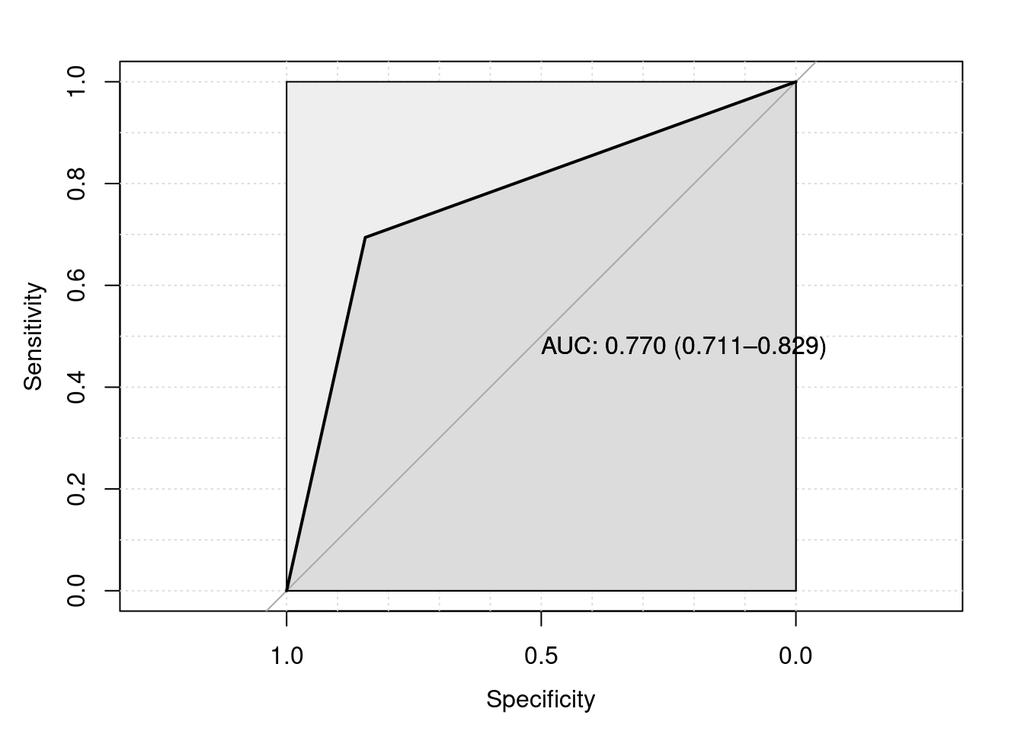

```r
test.results <- test.results %>%
  mutate(pred = as.numeric(pred))
pROC_obj <- roc(as.numeric(as.factor(test.results$survived)), test.results$pred,
            smoothed = TRUE,
            ci=TRUE, ci.alpha=0.9, stratified=FALSE,
            plot=TRUE, auc.polygon=TRUE, max.auc.polygon=TRUE, grid=TRUE,
            print.auc=TRUE, show.thres=TRUE)
```

Bei Naive Bates kann das Feature Embarked keine Verbesserung hervorrufen.

Decision Tree

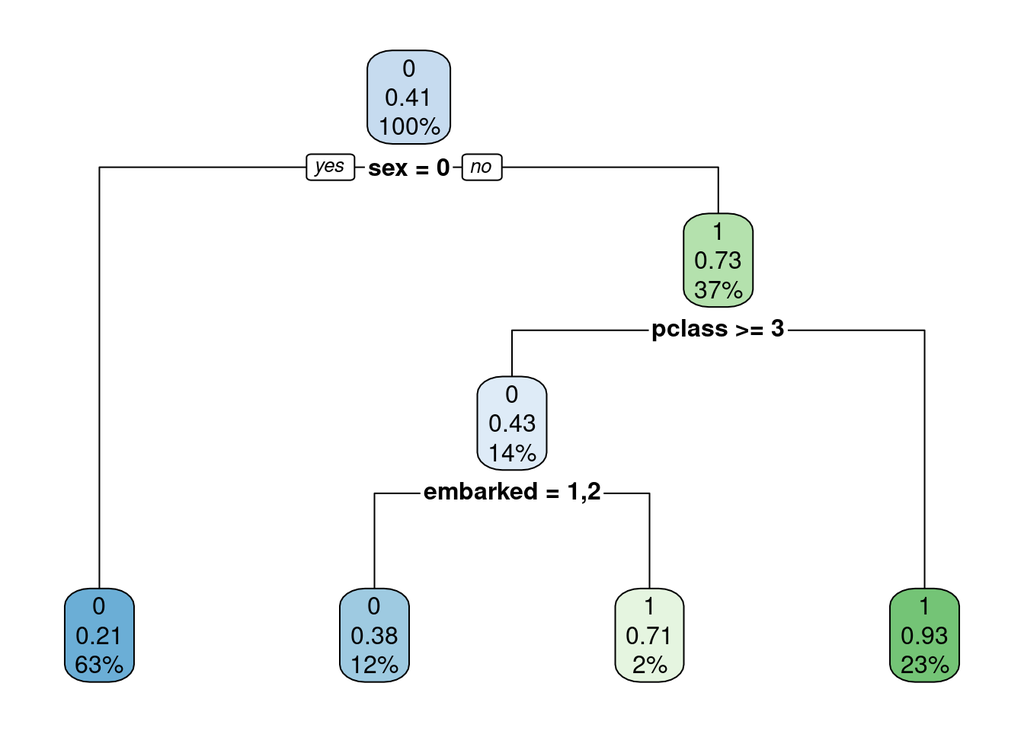

```r
library(rpart)
library(rpart.plot)
tree<- rpart(survived~., data = training, method = 'class')
rpart.plot(tree)
```

```r
dt_results <- predict(tree, testing[,-1], type = 'prob')
head(model.results.dt <- cbind(testing,dt_results),500)
```

|  | survived | pclass | age | sex | embarked | fare | 0 | 1 |
| --- | --- | --- | --- | --- | --- | --- | --- | --- |
| 1 | 1 | 1 | 0.9167 | 0 | 2 | 0.9167 | 0.78666667 | 0.2133333 |
| 2 | 1 | 1 | 18.0000 | 1 | 0 | 18.0000 | 0.07368421 | 0.9263158 |
| 3 | 1 | 1 | 24.0000 | 1 | 0 | 24.0000 | 0.07368421 | 0.9263158 |
| 4 | 0 | 1 | 24.0000 | 0 | 0 | 24.0000 | 0.78666667 | 0.2133333 |
| 5 | 0 | 1 | 25.0000 | 0 | 0 | 25.0000 | 0.78666667 | 0.2133333 |
| 6 | 0 | 1 | 42.0000 | 0 | 2 | 42.0000 | 0.78666667 | 0.2133333 |
| 7 | 1 | 1 | 59.0000 | 1 | 2 | 59.0000 | 0.07368421 | 0.9263158 |
| 8 | 1 | 1 | 60.0000 | 1 | 0 | 60.0000 | 0.07368421 | 0.9263158 |
| 9 | 0 | 1 | 45.0000 | 0 | 2 | 45.0000 | 0.78666667 | 0.2133333 |
| 10 | 1 | 1 | 58.0000 | 1 | 0 | 58.0000 | 0.07368421 | 0.9263158 |

[output cut: 198 more lines]

```r
test.results2 <- test.results %>%
  mutate(pred = ifelse(pred>=0.5,1,0))
table(test.results2$pred, testing$survived)
```

```
##
##       0   1
##   1 123  85
```

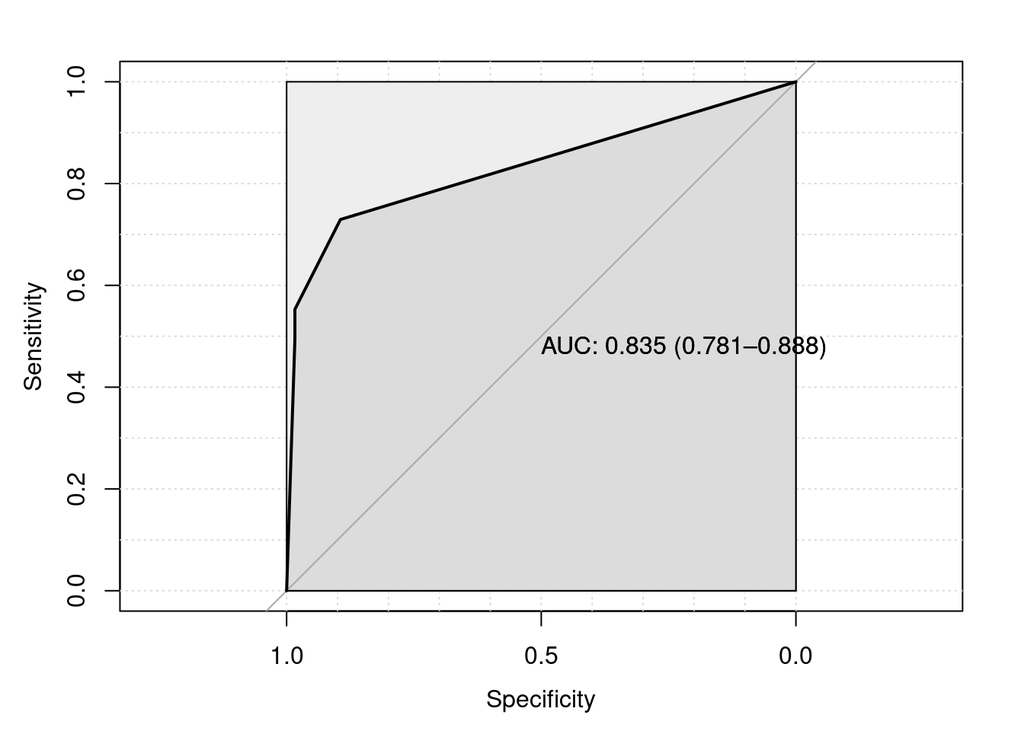

```r
pROC_obj <- roc(model.results.dt$survived,model.results.dt$`1`,
            smoothed = TRUE,
            # arguments for ci
            ci=TRUE, ci.alpha=0.9, stratified=FALSE,
            # arguments for plot
            plot=TRUE, auc.polygon=TRUE, max.auc.polygon=TRUE, grid=TRUE,
            print.auc=TRUE, show.thres=TRUE)
```

Den besten Wert konnte wieder Mal der Decision Tree erzielen, jedoch nicht so hoch, wie mit anderen Features. Nun zu der Erklärung der Unterschiede in der Performance der Algorithmen: Bei SVM wirkt es so als ob nur signifikante Features, wie Geschlecht, Alter und Klasse eine Verbesserung des AUC-Werts ermöglichen können. Jedes von mir ausgesuchte Feature hat die Performance entweder verschlechtert oder sie ist gleichgeblieben.Bei Naive Bates werden irrelevante Features für das Überleben der Passagiere noch härter bestragt. Es wirkt fast so als wäre Naive Bates ein Faktor von SVM, welcher sich entweder ins positive oder negative auswirkt. Dies könnte daran liegen, dass Naive Bates mehrere Vorgänge hat und die Daten “mehrmals durchgeht”. Beim Decision Tree hingegen scheint jedes Feature ein wichtiges für die Überlebenschanchen der Passagiere zu sein. Auch welche die eigentlich irrelevant sein sollten (fare und parch zum Beispiel). Daher würde ich behaupten, umso mehr Features beim Decision Tree desto besser wird auch der AUC-Wert. Ist das sinnig? Eigentlich nicht. Ich habe es daher auch vermieden alle Features gemeinsam in den verschiedenen Modelle zu testen, da dies nur dazu führen würde das der Decision Tree ziemlich gut abschneiden würde und SVM Naive Bates eher nicht.